# ME323 - Introdução aos Modelos Probabilísticos

## Variável Aleatória Discreta

## Variável Aleatória

- Em um experimento aleatório, muitas vezes não estamos interessados nos detalhes do resultado do evento, mas sim em alguma quantidade numérica obtida a partir do experimento.
- Ex: lançamento de dois dados. O interesse pode estar apenas na soma, não nos resultados individuais dos dados.
- Quantidades de interesse resultantes de experimento aleatório são denominadas **variáveis aleatórias**.
- Cada resultado possível de uma variável aleatória (v.a.) tem associado uma probabilidade. O conjunto de todos os resultados possíveis e as respectivas probabilidades é denominado **distribuição de probabilidade**.

## Exemplo: Lançamento de dois dados

Estamos interessados na soma dos resultados.

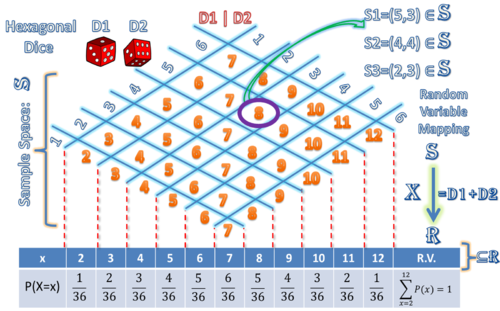

## Definição: Variável Aleatória Discreta

Uma **função** \(X\) que associa a cada elemento do espaço amostral um valor num conjunto enumerável de pontos da reta é denominada **variável aleatória discreta**.

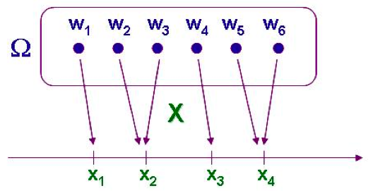

## Exemplo: Lançamento de uma moeda

\(X=1\) se cara e \(X=0\) se coroa

[figure not shown]

## Exemplo: Lançamento de uma moeda duas vezes

\(X\) é a soma dos resultados (coroa é 0 e cara é 1).

[figure not shown]

## Distribuição de Probabilidade

## Distribuição de Probabilidade - v.a. discreta

- Quando a v.a. assume valores inteiros: v.a. **discreta**.
- A distribuição de probabilidade associa uma probabilidade \(P(X=x)\) para cada valor possível, \(x\), da variável aleatória \(X\).
- Para cada valor de \(x\), \(0\leq P(X=x)\leq 1\).
- Soma das probabilidades de todos os valores possíveis de \(X\) é igual a 1.

## Distribuição de Probabilidade - v.a. discreta

- Seja \(X\) uma v.a. discreta com \(n\) valores possíveis denotados por \(x_1,x_2,\ldots,x_n\).
- \(P(X=x_i)\) denota a probabilidade de que a v.a. \(X\) assuma o valor \(x_i\).
- O conjunto de todas essas probabilidades (para cada \(x_i\)) representa a **distribuição de probabilidade** de \(X\).

| \(X\) | \(x_1\) | \(x_2\) | \(x_3\) | \(\ldots\) |
| --- | --- | --- | --- | --- |
| \(P(X=x)\) | \(P(X=x_1)\) | \(P(X=x_2)\) | \(P(X=x_3)\) | \(\ldots\) |

- Como \(X\) só pode assumir valores entre \(x_1,x_2,\ldots,x_n\), temos que: \[\sum_{i=1}^n P(X=x_i) =1\]

## Exemplo

> Suponha que \(X\) seja uma v.a. discreta que assume os valores \(1\), \(2\) e \(3\).

> Se \(P(X=1)=0.4\) e \(P(X=2)=0.1\), qual o valor de \(P(X=3)\)?

> \[\sum_{i=1}^nP(X=x_i)=1\]

> \[P(X=1)+P(X=2)+P(X=3)=1\]

> \[0.4+0.1+P(X=3)=1\]

> \[P(X=3)=0.5\]

## Distribuição de Probabilidade

Podemos representar a distribuição de probabilidade com o seguinte gráfico:

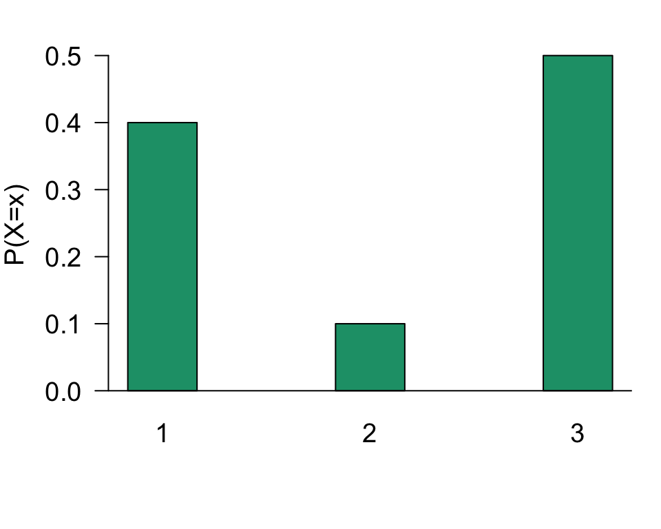

A altura de cada barra representa a probabilidade daquele valor.

## Exemplo: Vendedor

Um vendedor de enciclopédias visita cada casa duas vezes.

> Com anos de experiência, ele acredita que a probabilidade de uma venda logo na primeira visita é 0.3.

> Já na segunda visita, ele acredita que a probabilidade de venda seja 0.6. Ele acredita também que o resultado em cada visita seja independente.

> Qual é a distribuição de probabilidade da v.a. \(X\): número de vendas feitas em uma casa?

## Exemplo: Vendedor

Considere os eventos:

- \(V_1\) = {venda na primeira visita}
- \(V_2\) = {venda na segunda visita}

Espaço amostral do fenômeno aleatório:

> \[\Omega=\{ (V_1^c \cap V_2^c), (V_1 \cap V_2^c), (V_1^c \cap V_2), (V_1 \cap V_2)\}\]

> Então, a v.a. \(X\) pode assumir os valores \(0\), \(1\) ou \(2\).

> Temos \(X= 0\) se nenhuma venda ocorrer nas duas visitas.

\[\begin{aligned} P(X=0) = & P(V_1^c \cap V_2^c) \overset{ind}{=} P(V_1^c) P(V_2^c) \\ = & [1-P(V_1)] [1-P(V_2)] = (1-0.3)(1-0.6)=0.28 \end{aligned}\]

## Exemplo: Vendedor

- \(X=1\) quando ocorre uma venda apenas na primeira visita **ou** uma venda apenas segunda visita.

Então, \[\begin{aligned} P(X=1) = & P[(V_1 \cap V_2^c) \cup (V_1^c \cap V_2)] \\ = & P(V_1 \cap V_2^c) + P(V_1^c \cap V_2) \\ \overset{ind}{=} & P(V_1)P(V_2^c) + P(V_1^c)P(V_2) \\ = & (0.3)(1-0.6) + (1-0.3)(0.6) \\ = & 0.54 \end{aligned}\]

## Exemplo: Vendedor

- \(X=2\) quando ocorre uma venda nas duas visitas.

\[ \begin{aligned} P(X=2) = & P(V_1 \cap V_2) \\ \overset{ind}{=} & P(V_1)P(V_2) = (0.3)(0.6) = 0.18 \end{aligned} \]

> Satisfaz a propriedade:

\[\begin{aligned} \sum_{i=0}^2 P(X=i) &= P(X=0)+P(X=1)+P(X=2) \\ &=0.28+0.54+0.18=1 \end{aligned} \]

| \(X\) | 0 | 1 | 2 |
| --- | --- | --- | --- |
| \(P(X=x)\) | 0.28 | 0.54 | 0.18 |

## Exemplo: Comissão

O Departamento de Estatística é formado por 35 professores, sendo 21 homens e 14 mulheres.

> Uma comissão de 3 professores será constituída sorteando, ao acaso, três membros do departamento.

> Qual é a probabilidade da comissão ser formada por pelo menos duas mulheres?

> Seja \(X\) o número de mulheres na comissão. \(X\) pode assumir os valores: 0, 1, 2 e 3.

> Seja \(X\) o número de mulheres na comissão. \(X\) pode assumir os valores: 0, 1, 2 e 3.

> \[P(X=0)=\frac{\binom{21}{3}\binom{14}{0}}{\binom{35}{3}}=0.203\]

> \[P(X=1)=\frac{\binom{21}{2}\binom{14}{1}}{\binom{35}{3}}=0.450\]

> \[P(X=2)=\frac{\binom{21}{1}\binom{14}{2}}{\binom{35}{3}}=0.291\]

> \[P(X=3)=\frac{\binom{21}{0}\binom{14}{3}}{\binom{35}{3}}=0.056\]

> Veja que \(\sum_{i=0}^3P(X=i)=1\).

> Probabilidade da comissão ter pelo menos duas mulheres: \[P(X\geq2)=P(X=2)+P(X=3)=0.347\]

## Exemplo: Comissão

A distribuição de probabilidade de \(X\) é dada por:

| \(X\) | 0 | 1 | 2 | 3 |
| --- | --- | --- | --- | --- |
| \(P(X=x)\) | 0.203 | 0.450 | 0.291 | 0.056 |

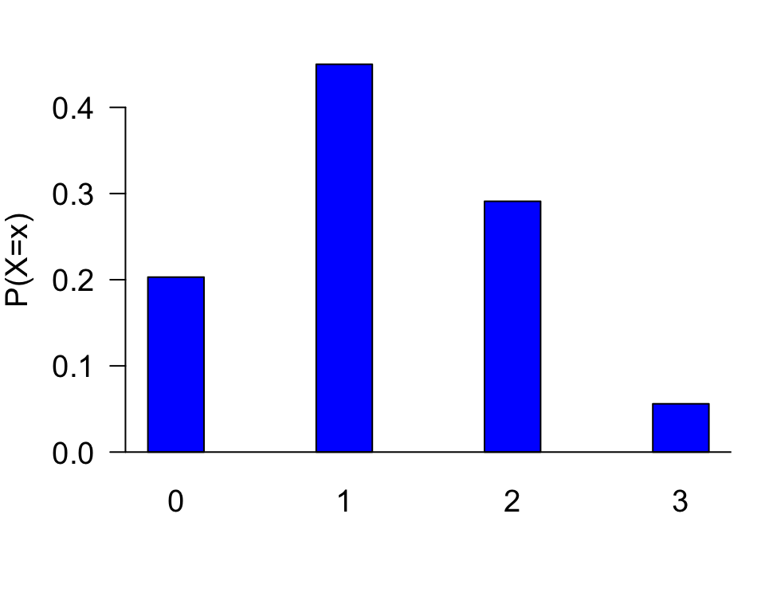

## Exemplo: Comissão

Outra maneira para calcular as probabilidades:

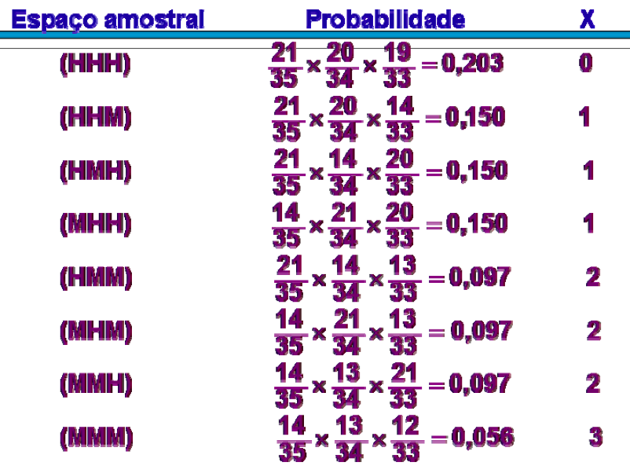

## Exemplo: Lançamento de dois dados

Qual a probabilidade da soma ser menor do que 6?

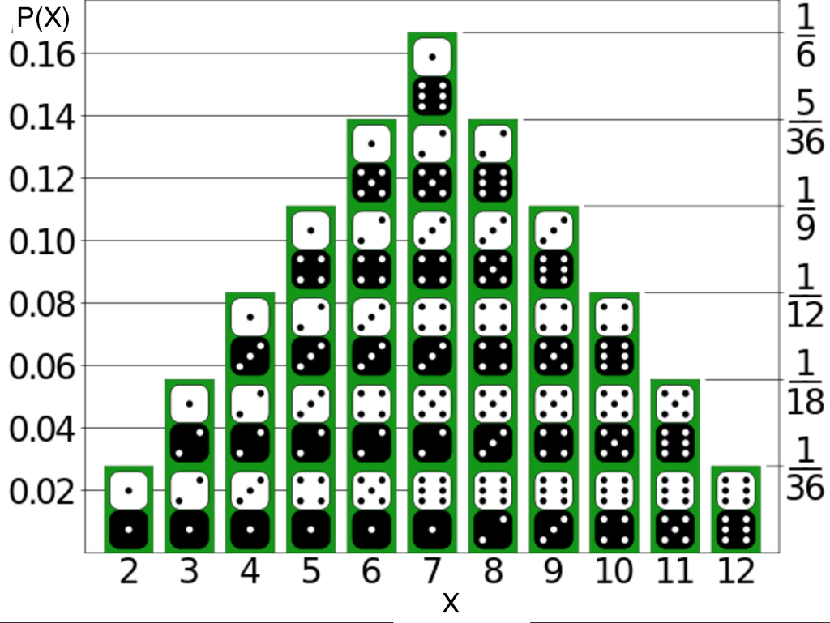

\(X\): soma dos dados.

\(P(X<6) = P(X=5) + P(X=4) + P(X=3) + P(X=2) = \frac{10}{36}\)

## Exemplo: Lançamento de dois dados

\(Y\): máximo resultado no lançamento de 2 dados.

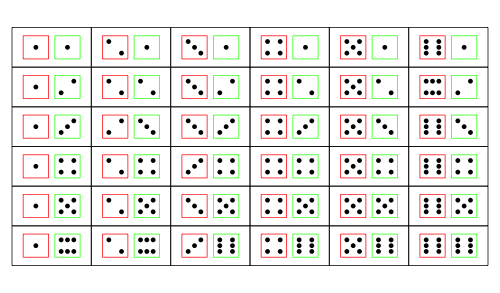

| \(Y\) | 1 | 2 | 3 | 4 | 5 | 6 |
| --- | --- | --- | --- | --- | --- | --- |
| \(P(Y=y)\) | 1/36 | 3/36 | 5/36 | 7/36 | 9/36 | 11/36 |

## Exemplo: Lançamento de dois dados

\(Z\): diferença entre os pontos do segundo e do primeiro lançamento.

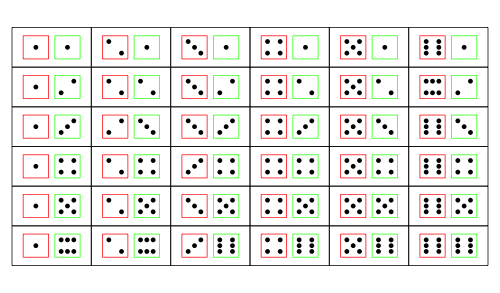

[output not shown]

## Exemplo: Construção

Na construção de um certo prédio, as fundações devem atingir 15 metros de profundidade, e para cada 5 metros de estacas colocadas, o operador anota se houve alteração no ritmo de perfuração previamente estabelecido.

Essa alteração é resultado de mudanças para mais ou para menos na resistência do subsolo.

Nos dois casos, medidas corretivas serão necessárias, encarecendo o custo da obra.

- com base em avaliações geológicas, admite-se que a probabilidade de ocorrência de alterações é de 0.1 para cada 5 metros.
- o custo básico inicial é de 100 UPCs (Unidades Padrão de Construção) e será acrescido de 50k, com k representando o número de alterações observadas.

## Exemplo: Construção

- Como se comporta a variável Custo de Obra de fundações?
- Assumimos que as alterações ocorrem independentemente entre cada um dos três intervalos de 5 metros.
- \(A=\) ocorrência de alterações em cada intervalo.
- 3 etapas \(\quad \Rightarrow \quad\) \(2 \times 2 \times 2 = 2^{3} = 8\) possibilidades.
- Espaço Amostral

\[\Omega = \{AAA, AAA^c, AA^cA, A^cAA, AA^cA^c, A^cAA^c, A^cA^cA, A^cA^cA^c \}\]

| Evento | Probabilidade | Custo |
| --- | --- | --- |
| \(AAA\) | \((0.1)^{3}=0.001\) | 250 |
| \(AAA^c\) | \((0.1)^{2}(0.9)=0.009\) | 200 |
| \(AA^cA\) | \((0.1)^{2}(0.9)=0.009\) | 200 |
| \(A^cAA\) | \((0.1)^{2}(0.9)=0.009\) | 200 |
| \(AA^cA^c\) | \((0.1)(0.9)^{2}=0.081\) | 150 |
| \(A^cAA^c\) | \((0.1)(0.9)^{2}=0.081\) | 150 |
| \(A^cA^cA\) | \((0.1)(0.9)^{2}=0.081\) | 150 |
| \(A^cA^cA^c\) | \((0.9)^{3}=0.729\) | 100 |

Note que associamos a cada evento do espaço amostral um valor da variável \(C\) (custo), e eventos diferentes podem corresponder ao mesmo valor de \(C\):

> \[c_{1}=100, \quad c_{2}=150, \quad c_{3}=200, \quad c_{4}=250\]
- \(P\left(C=c_{1}\right)=P\left(A^cA^cA^c\right)=0.729\)
- \(P\left(C=c_{2}\right)=P\left(AA^cA^c \cup A^cAA^c \cup A^cA^cA\right)=3\times 0.081=0.243\)
- \(P\left(C=c_{3}\right)=P\left(AAA^c \cup AA^cA \cup A^cAA\right)=3 \times 0.009=0.027\)
- \(P\left(C=c_{4}\right)=P\left(AAA\right)=0.001\)

O comportamento de \(C\) estudado através da probabilidade de ocorrência pode auxiliar na previsão de gastos e na elaboração de orçamentos:

| \(C\) | 100 | 150 | 200 | 250 |
| --- | --- | --- | --- | --- |
| \(P(C=c)\) | 0.729 | 0.243 | 0.027 | 0.001 |

## Exemplo: Lançamento de uma moeda duas vezes

[figure not shown]

Espaço amostral: \[\Omega=\{CC, C \bar C, \bar C C, \bar C \bar C\},\] em que \(C=\) cara e \(\bar C=\) coroa.

> Seja a v.a. \(X=\) número de caras em dois lançamentos.

| \(X\) | 0 | 1 | 2 |
| --- | --- | --- | --- |
| \(P(X=x)\) | \(\displaystyle P\left(\bar C \bar C\right)=\frac{1}{4}\) | \(\displaystyle P\left(C \bar C \cup \bar C C\right)=\frac{2}{4}=\frac{1}{2}\) | \(\displaystyle P\left(CC\right)=\frac{1}{4}\) |

## Função de Distribuição Acumulada

## Exemplo: Vacina

Um grupo de 1000 crianças foi analisado para determinar a efetividade de uma vacina contra um tipo de alergia. As crianças recebiam uma dose de vacina e após um mês passavam por um novo teste. Caso ainda tivessem tido alguma reação alérgica, recebiam outra dose.

> Variável de interesse: X = número de doses.

| Doses (\(X\)) | 1 | 2 | 3 | 4 | 5 |
| --- | --- | --- | --- | --- | --- |
| Frequência | 245 | 288 | 256 | 145 | 66 |

> Uma criança é sorteada ao acaso, qual a probabilidade dela ter recebido 2 doses?

> \[P(X=2) = \frac{288}{1000}=0.288\]

## Exemplo: Vacina

Distribuição de Probabilidade de \(X\)

| Doses (\(X\)) | 1 | 2 | 3 | 4 | 5 |
| --- | --- | --- | --- | --- | --- |
| \(P(X=x)\) | 0.245 | 0.288 | 0.256 | 0.145 | 0.066 |

Qual a probabilidade da criança ter recebido até duas doses?

\[ \begin{aligned} P\left(X \leq 2\right) &= P\left(X=1\right)+P\left(X=2\right) \\ &=0.245+0.288\\ &=0.533 \end{aligned} \]

## Função de Distribuição Acumulada

A função de distribuição acumulada (f.d.a.) de uma variável aleatória \(X\) é definida por \[F\left(x\right)=P\left(X \leq x\right), \quad x\in\mathbb{R}\]

Assim, se \(X\) assume os valores em \(\{x_{1},x_{2},...,x_{n}\}\), em que \(x_1 < x_2 < \ldots < x_n\):

\(F\left(x_{1}\right)=P\left(X=x_{1}\right)\)

\(F\left(x_{2}\right)=P\left(X=x_{1}\right) + P\left(X=x_{2}\right)\)

\(\vdots\)

\(F\left(x_{n}\right)=P\left(X=x_{1}\right) + ... + P\left(X=x_{n}\right)\)

## Exemplo: Vacina

| Doses (\(X\)) | 1 | 2 | 3 | 4 | 5 |
| --- | --- | --- | --- | --- | --- |
| \(P(X=x)\) | 0.245 | 0.288 | 0.256 | 0.145 | 0.066 |

> Note que a f.d.a. de \(X=\) número de doses é definida para qualquer valor real, logo:

\[ F(x) = \begin{cases} 0 & x < 1 \\ 0.245 & 1 \leq x < 2 \\ 0.533 & 2 \leq x < 3 \\ 0.789 & 3 \leq x < 4 \\ 0.934 & 4 \leq x < 5 \\ 1 & x \geq 5 \\ \end{cases} \]

## Exemplo: Vacina

Função de distribuição acumulada (f.d.a.) do número de doses (\(X\))

\[ F(x) = \begin{cases} 0 & x < 1 \\ 0.245 & 1 \leq x < 2 \\ 0.533 & 2 \leq x < 3 \\ 0.789 & 3 \leq x < 4 \\ 0.934 & 4 \leq x < 5 \\ 1 & x \geq 5 \\ \end{cases} \]

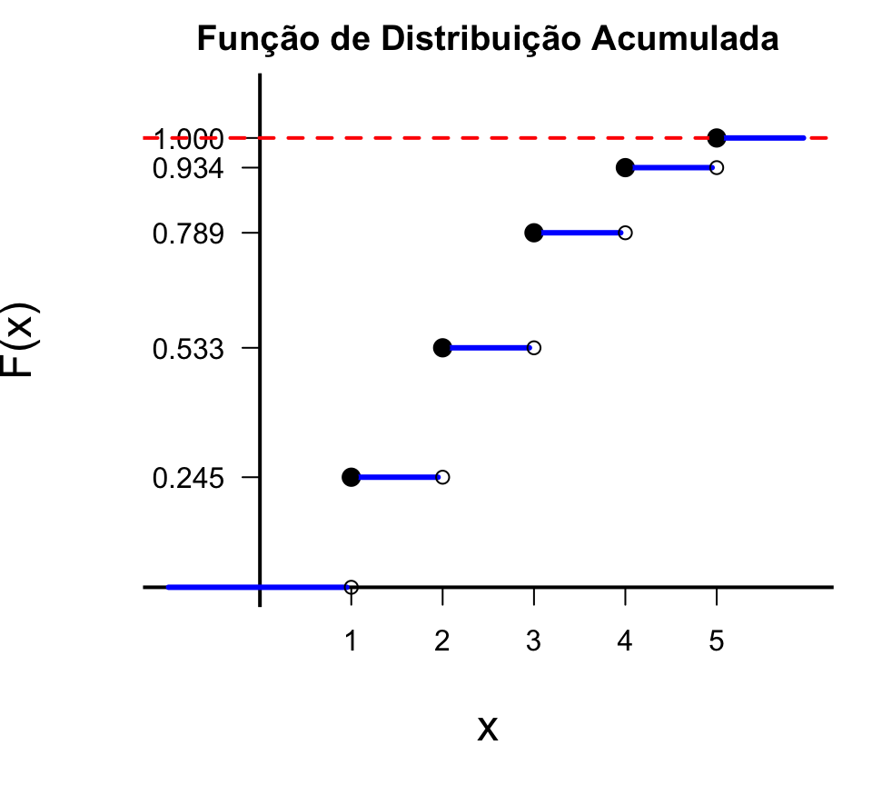

## Exemplo: Comissão

O Departamento de Estatística é formado por 35 professores, sendo 21 homens e 14 mulheres. Uma comissão de 3 professores será constituída sorteando, ao acaso, três membros do departamento.

> Seja \(X\) o número de mulheres na comissão. \(X\) pode ser 0, 1, 2 e 3.

| \(X\) | 0 | 1 | 2 | 3 |
| --- | --- | --- | --- | --- |
| \(P(X=x)\) | 0.203 | 0.450 | 0.291 | 0.056 |

\[ F(x) = P(X \leq x) = \begin{cases} 0, & \mbox{se } x<0 \\ 0.203 & \mbox{se } 0\leq x<1\\ 0.653 & \mbox{se } 1\leq x<2\\ 0.944 & \mbox{se } 2\leq x<3\\ 1 & \mbox{se } x\geq3 \end{cases} \]

## Exemplo: Comissão

Função de distribuição acumulada de \(X\): número de mulheres na comissão. \[ F(x) = \begin{cases} 0, & \mbox{se } x<0 \\ 0.203 & \mbox{se } 0\leq x<1\\ 0.653 & \mbox{se } 1\leq x<2\\ 0.944 & \mbox{se } 2\leq x<3\\ 1 & \mbox{se } x\geq3 \end{cases} \]

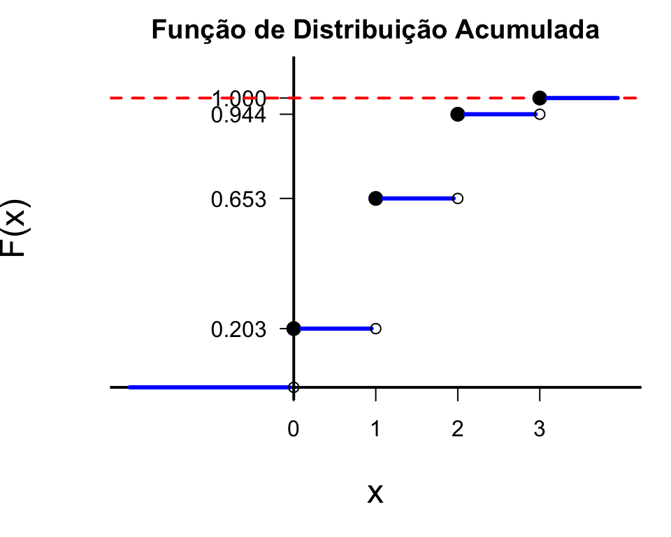

## Esperança

## Esperança: variável aleatória discreta

Seja \(X\) uma v.a. discreta assumindo valores possíveis no conjunto \(D\).

A **esperança** (ou valor esperado/médio) da variável \(X\) é dada por: \[\mathbb E(X)=\mu_X=\sum_{x\in D} x P(X=x)\]

> Interpretação: a esperança de \(X\) é a média ponderada de todos os valores possíveis de \(X\), onde o peso de cada valor é sua respectiva probabilidade.

## Esperança - Exemplos

- Suponha que \(X\) assuma os valores 0 ou 1 com igual probabilidade, ou seja,

\[P(X=0)=P(X=1)=\frac{1}{2}\]

> \[\mathbb E(X)= 0\times P(X=0)+1\times P(X=1)=\frac{1}{2}\]
- Suponha que \(X\) assuma os valores 0 ou 1 com as seguintes probabilidades,

\[P(X=0)=\frac{2}{3} \quad \mbox{e} \quad P(X=1)=\frac{1}{3}\]

> \[\mathbb E(X)= 0\times P(X=0)+1\times P(X=1)= 0\times\frac{2}{3}+1\times\frac{1}{3}=\frac{1}{3}\]

> Veja que nesses dois exemplos: \(\mathbb E(X) = P(X=1)\)

## Exemplo: Lançamento de um dado

> \(X\) é a v.a. representando o resultado do lançamento.

> \[P(X=i)=\frac{1}{6}, \qquad i=1,2,3,4,5,6\]

> \[\mathbb E(X)= 1\times \frac{1}{6} + 2\times \frac{1}{6}+3\times \frac{1}{6}+4\times \frac{1}{6}+5\times \frac{1}{6}+6\times \frac{1}{6}=3.5\]

> Neste caso, a esperança de \(X\) não é igual a nenhum dos valores possíveis de \(X\).

> Não podemos interpretar \(\mathbb E(X)\) como o valor que esperamos que \(X\) irá assumir, mas sim como uma média dos valores observados de \(X\) ao longo de muitas repetições do experimento aleatório.

> Se jogarmos o dado muitas vezes e calcularmos uma média de todos os resultados obtidos, essa média será aproximadamente 3.5.

## Exemplo: Seguros

Uma companhia de seguros determina o [prêmio](http://pt.wikipedia.org/wiki/Prêmio_de_seguro) anual do seguro de vida de maneira a obter um lucro esperado de 1% do valor que o segurado recebe em caso de morte.

Encontre o valor do prêmio anual para um seguro de vida no valor de R$200 mil assumindo que a probabilidade do cliente morrer naquele ano é 0.02.

- \(A\): prêmio anual
- \(X\): lucro da companhia no ano para o cliente
- Então,

> \[X = \begin{cases} A, & \mbox{se o cliente sobrevive} \\ A-200000, & \mbox{se o cliente morre} \end{cases} \]

## Exemplo: Seguros

> \(\mathbb E(X)= A\times P(\mbox{sobreviver}) + (A-200000)\times P(\mbox{morrer})\)

> \(\mathbb E(X)=A\times 0.98 +(A-200000)\times 0.02\)

> \(\mathbb E(X)=A-4000\)

> Companhia quer lucro esperado de 1% do valor recebido em caso de morte: R$2000.

> \(\mathbb E(X) = 2000 = A - 4000\)

Portanto, \(A = R\$6000\) é o valor do prêmio anual.

## Exemplo: Montagem

Um empresário pretende estabelecer uma firma para montagem de um componente mecânico. Cada peça é composta de duas partes, \(A\) e \(B\), cada uma com uma chance específica de ser defeituosa. Só é possível verificar a qualidade das peças depois que elas são montadas.

- Se ambas são defeituosas, a peça é descartada e dá um prejuízo de \(\$5\).
- Se a peça \(B\) é defeituosa, ainda é possível reparar a peça e obter um lucro de \(\$5\).
- De maneira semelhante, se \(A\) é defeituosa, o reparo permite vender a peça inteira com um lucro de \(\$10\).
- Se as duas peças são boas, o lucro é de \(\$15\).

> **Pergunta:** Qual o lucro esperado por peça produzida?

## Exemplo: Montagem

Seja \(A\) o evento indicando que a peça A está perfeita.

> Então \(A^c\) indica que a peça A está com defeito.

> Seja \(B\) o evento indicando que a peça B está perfeita.

> Então \(B^c\) indica que a peça B está com defeito.

Cada uma das configurações está associada a uma probabilidade:

\[P(A \cap B)=0.56 \qquad P(A^c \cap B)=0.23\]

\[P(A \cap B^c)=0.02 \qquad P(A^c \cap B^c)=0.19\]

> Como podemos descrever a distribuição do lucro por componente?

## Exemplo: Montagem

\(P(A \cap B)=0.56 \quad P(A^c \cap B)=0.23 \quad P(A \cap B^c)=0.02 \quad P(A^c \cap B^c)=0.19\)

Seja \(X\) a variável indicando o lucro na produção de um componente.

- \(X\) assume o valor 15 se as peças A e B estão ok, o que ocorre com probabilidade 0.56.
- \(X\) assume o valor 10 se apenas A apresentar defeito, o que ocorre com probabilidade 0.23.
- \(X\) assume o valor 5 se apenas B apresentar defeito, o que ocorre com probabilidade 0.02.
- \(X\) assume o valor \(-5\) se tanto A quanto B apresentarem defeito, o que ocorre com probabilidade 0.19.

## Exemplo: Montagem

Distribuição de probabilidade para a variável aleatória \(X\):

| \(X\) | \(-5\) | \(5\) | \(10\) | \(15\) |
| --- | --- | --- | --- | --- |
| \(P(X=x)\) | 0.19 | 0.02 | 0.23 | 0.56 |

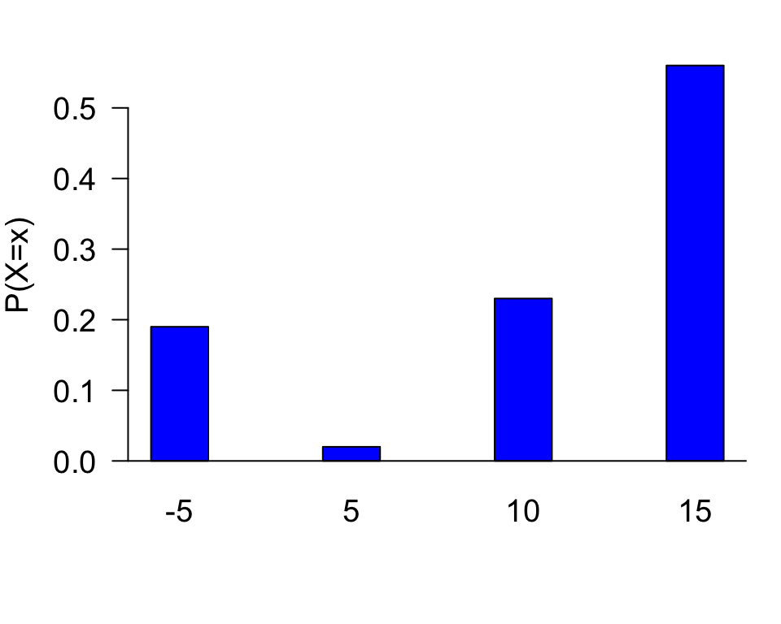

## Exemplo: Montagem

| \(X\) | \(-5\) | \(5\) | \(10\) | \(15\) |
| --- | --- | --- | --- | --- |
| \(P(X=x)\) | 0.19 | 0.02 | 0.23 | 0.56 |

Função de Distribuição Acumulada:

\[ F(x) = \begin{cases} 0 & \mbox{se} & x < -5\\ 0.19 & \mbox{se} & -5 \leq x < 5\\ 0.21 & \mbox{se} & 5 \leq x < 10\\ 0.44 & \mbox{se} & 10 \leq x < 15\\ 1 & \mbox{se} & x \geq 15\\ \end{cases} \]

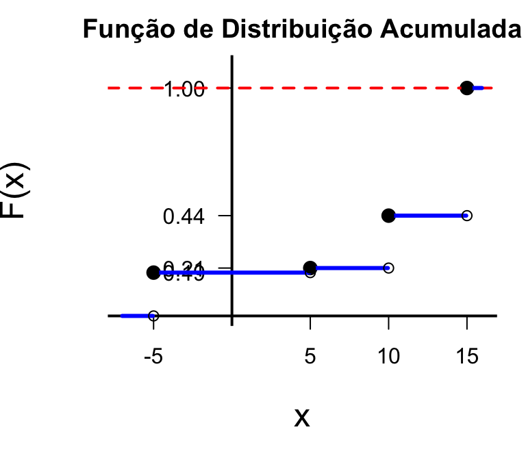

## Exemplo: Montagem

O empresário quer saber: *Qual o lucro médio por conjunto montado que espero conseguir?*

| \(X\) | \(-5\) | \(5\) | \(10\) | \(15\) |
| --- | --- | --- | --- | --- |
| \(P(X=x)\) | 0.19 | 0.02 | 0.23 | 0.56 |

> Lembrem-se que a esperança de uma v.a. \(X\) com valores \(x_1, x_2, \ldots, x_n\) é:

\[\mathbb E\left( X \right) = \sum_{i=1}^n x_i P(X=x_i)\]

> Para saber o lucro esperado, basta aplicar a fórmula:

\[\begin{aligned} \mathbb E \left( X \right) &= -5\times0.19 + 5\times0.02 + 10\times0.23 + 15\times0.56 \\ & = 9.85 \end{aligned}\]

## Exemplo: Pedágio

[figure not shown]

Você, cansado de esperar em filas de pedágio com frequência, está considerando assinar o serviço de pagamento eletrônico.

Dentre as opções oferecidas, você se interessa pelas duas seguintes:

- Plano 1: Clássico
- Plano 2: BR Adesão Zero

## Exemplo: Pedágio

[figure not shown]

No plano Clássico:

- obrigatório fazer adesão novamente após 5 anos.
- em caso de perda/roubo/troca é preciso pagar a taxa de substituição.

> Assumindo que não há roubo/perda, mas apenas troca do veículo e que não há o desconto na adesão para renovar após 5 anos, como decidir?

> Podemos fazer um exemplo de acordo com o período em que vamos assinar o plano escolhido.

## Exemplo: Pedágio

Seja a v.a. \(T\): idade do veículo até a troca.

Função de distribuição acumulada é dada por:

\[ F(t) = \begin{cases} 0 & \mbox{se} & t < 2\\ 0.1 & \mbox{se} & 2 \leq t < 3\\ 0.2 & \mbox{se} & 3 \leq t < 4\\ 0.5 & \mbox{se} & 4 \leq t < 5\\ 0.7 & \mbox{se} & 5 \leq t < 6\\ 0.9 & \mbox{se} & 6 \leq t < 7\\ 1 & \mbox{se} & t \geq 7 \\ \end{cases} \]

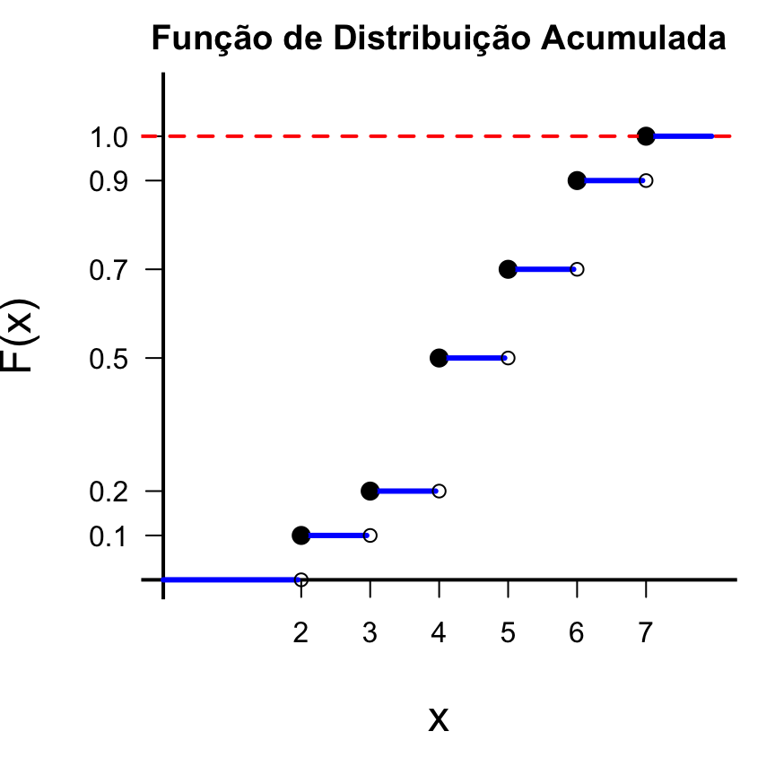

Assumindo que você queira assinar por um período de 3 anos. Vamos definir:

- \(C_1\): custo do plano 1 por 3 anos.

Probabilidade de trocar de carro em até 3 anos: \(0.2\)

Portanto, \(C_1\) assume os valores:

\[ C_1 = \begin{cases} 73.16+13.05\times 12 \times 3 = 542.96, & \mbox{com probabilidade 0.8} \\ 73.16+13.05\times 12 \times 3+43.83=586.79, & \mbox{com probabilidade 0.2} \end{cases} \]

> \[\mathbb E(C_1)=542.96\times 0.8+586.79\times 0.2=551.73\]
- \(C_2\): custo do plano 2 por 3 anos.

\(C_2\) assume o valor \(17.28\times 12 \times 3 = 622.08\), com probabilidade 1

\[\mathbb E(C_2)=622.08\]

Assumindo que você queira assinar por um período de 6 anos. Vamos definir:

- \(C_1\): custo do plano 1 por 6 anos.

Probabilidade de trocar de carro em até 6 anos: \(0.9\)

> Portanto, \(C_1\) assume os valores:

\[ C_1 = \begin{cases} 2\times73.16+13.05\times 12 \times 6 = 1085.92, & \mbox{com probabilidade 0.1} \\ 2\times73.16+13.05\times 12 \times 6+43.83=1129.75, & \mbox{com probabilidade 0.9} \end{cases} \]

> \[\mathbb E(C_1)=1085.92\times 0.1+1129.75\times 0.9=1125.37\]
- \(C_2\): custo do plano 2 por 6 anos.

\(C_2\) assume o valor \(17.28\times 12 \times 6= 1244.16\), com probabilidade 1

> \[\mathbb E(C_2)=1244.16\]

## Propriedades da Esperança

- Se \(Y=aX+b\), onde \(a\) e \(b\) são constantes, então:

\[E(Y)=E(aX+b)=aE(X)+b\]

- Se \(X_1, X_2, \ldots, X_n\) são variáveis aleatórias:

\[E\left( \sum_{i=1}^n X_i\right) = \sum_{i=1}^n E(X_i)\]

- Seja \(X\) uma v.a. discreta com valores possíveis no conjunto \(D\), então, para qualquer função \(g\): \[E[g(X)] = \sum_{x\in D} g(x) P(X=x)\]

## Exemplo

Seja \(X\) uma v.a. tal que:

\[ X= \begin{cases} 1, & \mbox{com probabilidade } p \\ 0, & \mbox{com probabilidade } 1-p \end{cases}\]

\[\mathbb E(X^2) = 1^2 \times p + 0^2 \times (1-p) = p\]

## Exemplo: venda de computadores

Uma loja de computadores comprou 3 computadores de certo modelo a \(\$500\) para serem vendidos a \(\$1000\) cada. O fabricante concordou em aceitar a devolução dos computadores não vendidos após 6 meses, por \(\$200\) cada. Seja \(X\) a quantidade de computadores vendidos. Supondo que: \(P(X=0)=0.1\), \(P(X=1)=0.2\), \(P(X=2)=0.3\) e \(P(X=3)=0.4\). Temos que o valor esperado de computadores vendidos é:

\[E(X) = 0\times 0.1 + 1\times 0.2 + 2\times 0.3 + 3\times 0.4 = 2\]

> Seja \(g(X)\) o lucro associado à venda de \(X\) computadores: receita menos o custo. \[g(X)=1000X + 200 (3-X) - 1500 = 800X-900\]

\[E[g(X)] = E(800X+900) = 800 E(X) - 900 = 700\]

## Variância

## Variância de variável aleatória discreta

- Vimos que a esperança nos dá a média ponderada de todos os resultados possíveis de uma v.a..
- No entanto, a esperança não descreve a dispersão dos dados.
- Considere as seguintes v.a.'s:

> \[U=0, \mbox{ com probabilidade 1}\] \[ V= \begin{cases} -1, & \mbox{com prob. 1/2} \\ \;\; 1, & \mbox{com prob. 1/2} \end{cases} \quad \mbox{e} \quad W= \begin{cases} -10, & \mbox{com prob. 1/2} \\ \;\; 10, & \mbox{com prob. 1/2} \end{cases} \]

> \[\mathbb E(U)=\mathbb E(V)=\mathbb E(W)=0\]

> Temos valores esperados idêndicos, mas dispersão é bem diferente para as três variáveis.

## Variância de variável aleatória discreta

Queremos uma medida para quantificar quão dispersos os valores da v.a. \(X\) estão da sua esperança.

> **Definição:** Se \(X\) é uma v.a. com esperança \(\mathbb E(X)=\mu\), então a variância de \(X\) é: \[Var(X)=\mathbb E[(X-\mu)^2]\]

> **Notação:** \(\sigma^2 = Var(X)\)
- Se \(X\) é uma v.a. discreta assumindo valores em \(D\):

> \[Var(X) = \sum_{x\in D} (x - \mu)^2 P(X=x)\]

## Propriedade Geral da Variância

**Definição:** \(Var(X)=\mathbb E([X-\mathbb E(X)]^{2})\)

> Uma forma alternativa de calcular a variância é usando a fórmula: \[Var(X) = \mathbb E(X^{2}) - [\mathbb E(X)]^{2}\]

> **Demonstração:** \[ \begin{aligned} \mathbb E([X-\mathbb E(X)]^{2}) &= \mathbb E([X-\mu]^{2}) \\ & = \mathbb E(X^{2}-2X\mu+\mu^{2}) = \mathbb E(X^{2}) - 2\mu \mathbb E(X) + \mu^{2} \\ & = \mathbb E(X^2) - 2\mu\mu + \mu^2 = \mathbb E(X^2)- 2\mu^{2} + \mu^{2} \\ & = \mathbb E(X^2) - \mu^{2} \\ & = \mathbb E(X^{2}) - [\mathbb E(X)]^2 \end{aligned} \]

## Exemplo

Encontre \(Var(X)\), onde \(X\) é uma v.a. tal que:

> \[ X= \begin{cases} 1, & \mbox{com probabilidade } p \\ 0, & \mbox{com probabilidade } 1-p \end{cases}\]

> \[ \begin{aligned} \mathbb E(X) &= 1\times p +0\times (1-p) = p \\ Var(X) &= \mathbb E(X^2) - p^2 \end{aligned} \]

Como calcular a \(\mathbb E(X^2)\)?

> \[ X^2= \begin{cases} 1^2, & \mbox{com probabilidade } p \\ 0^2, & \mbox{com probabilidade } 1-p \end{cases} \]

> \[ \begin{aligned} \mathbb E(X^2) &= 1\times p + 0\times (1-p) = p \\ Var(X) & = p-p^2 = p(1-p) \end{aligned} \]

## Propriedades da Variância

1. Para qualquer v.a. \(X\) e constantes \(a\) e \(b\): \[Var(aX + b) = a^2Var(X)\]

   Casos particulares:
   - \(Var(X+b) = Var(X)\)
   - \(Var(aX) = a^2 Var(X)\)
2. Se \(X_1, X_2, \ldots, X_n\) são variáveis aleatórias independentes: \[ Var \left(\sum_{i=1}^n X_i \right) = \sum_{i=1}^n Var(X_i)\]

## Exemplo

Considere uma urna contendo três bolas vermelhas e cinco pretas.

> Retire três bolas, sem reposição, e defina a variável aleatória \(X\) igual ao número de bolas pretas.

> Obtenha a distribuição de \(X\). Calcule a esperança e a variância.

> *Fonte*: Morettin | Bussab, Estatística Básica \(5^a\) edição, pág 135.

> Repare que não há reposição:
- a primeira extração tem 5 possibilidades em 8 de ser uma bola preta;
- a segunda terá 5 em 7 se a primeira for vermelha, ou 4 em 7 se a primeira foi preta, e assim por diante.

## Exemplo (continuação)

Retirar 3 bolas, sem reposição, de uma urna com 3 bolas vermelhas e 5 pretas

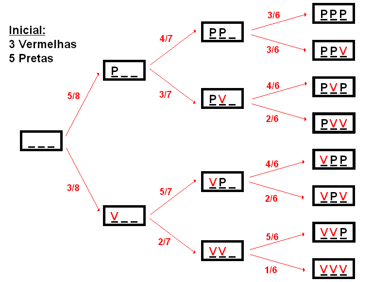

## Exemplo (continuação)

A partir do gráfico, podemos construir uma tabela com os eventos do espaço amostral:

| Extrações | Probabilidade | \(X=x\) |
| --- | --- | --- |
| PPP | \(5/8\times 4/7\times3/6 = 5/28\) | 3 |
| PPV | \(5/8\times4/7\times3/6 = 5/28\) | 2 |
| PVP | \(5/8\times3/7\times4/6 = 5/28\) | 2 |
| VPP | \(3/8\times5/7\times4/6 = 5/28\) | 2 |
| PVV | \(5/8\times3/7\times2/6 = 5/56\) | 1 |
| VPV | \(3/8\times5/7\times2/6 = 5/56\) | 1 |
| VVP | \(3/8\times2/7\times5/6 = 5/56\) | 1 |
| VVV | \(3/8\times2/7\times1/6 = 1/56\) | 0 |

## Exemplo (continuação)

Como \(X\) é o número de bolas pretas, temos que:

> Somando as probabilidades dos eventos, encontradas anteriormente, obtemos a função de distribuição de \(X\), \(p_X(x)\).

> | Eventos | \(X=x\) | \(p_X(x) = P(X=x)\) |
> | --- | --- | --- |
> | \(\{VVV\}\) | 0 | \(0.02\) |
> | \(\{VVP\} \cup \{VPV\} \cup \{PVV\}\) | 1 | 0.27 |
> | \(\{PPV\} \cup \{PVP\} \cup \{VPP\}\) | 2 | 0.53 |
> | \(\{PPP\}\) | 3 | 0.18 |

## Exemplo (continuação)

Podemos calcular a esperança e a variância de \(X\) a partir de sua função de probabilidade:

\[ \begin{aligned} \mu &= \mathbb E (X ) = \sum_{x=0}^3 xp_X (x) \\ & = 0 \times 0.02 + 1 \times 0.27 + 2 \times 0.53 + 3 \times 0.18 = 1.87 \\ \\ Var(X) & = \mathbb E[(X-\mu)^2] = \sum_{x=0}^3 (x-\mu)^2 p_X(x) \\ & = (0-1.87)^2 \times 0.02 + (1-1.87)^2 \times 0.27 + (2-1.87)^2\times 0.53 + (3-1.87)^2 \times 0.18= 0.51 \\ \\ \mbox{ou} \\ \\ Var(X) &= \mathbb E(X^2) - [\mathbb E(X)]^2 \\ &= (0^2 \times 0.02 + 1^2 \times 0.27 + 2^2 \times 0.53 + 3^2 \times 0.18) - (1.87)^2 = 0.51 \end{aligned} \]

## Exemplo

O tempo \(T\), em minutos, necessário para um operário processar certa peça é uma v.a. com a seguinte distribuição de probabilidade:

> | \(T\) | 2 | 3 | 4 | 5 | 6 | 7 |
> | --- | --- | --- | --- | --- | --- | --- |
> | \(P(T=t)\) | \(0.1\) | \(0.1\) | \(0.3\) | \(0.2\) | \(0.2\) | \(0.1\) |

1. Calcule o tempo médio de processamento.
2. Cada peça processada paga ao operador \(\$2.00\) mas, se ele processa a peça em menos de 6 minutos, ganha \(\$0.50\) por minuto poupado. Por exemplo, se ele processa a peça em 4 minutos, ganha um bônus de \(\$1.00\). Encontre a distribuição, a média e a variância da v.a. \(S\): quantia paga por peça.

*Fonte: Morettin & Bussab*, Estatística Básica \(5^a\) edição, pág 140.

## Exemplo (continuação)

1. Tempo médio de processamento \[ \begin{aligned} \mathbb E (T) & = \displaystyle \sum_{t=2}^7 t P(T=t) \\ & = 2\times 0.1 + 3\times 0.1 + 4\times 0.3 + 5\times 0.2 + 6\times 0.2 + 7\times 0.1 = 4.6 \end{aligned} \]
2. Podemos trocar os valores na tabela do tempo, pelo total ganho por peça. Note, contudo, que o operário receberá \(\$ 2.00\) no evento \(\{T=6\} \cup \{T=7\}\), logo somamos suas probabilidades. Seja \(S\) a v.a. "ganho final".

| \(S\) | \(\$4.00\) | \(\$3.50\) | \(\$3.00\) | \(\$2.50\) | \(\$2.00\) |
| --- | --- | --- | --- | --- | --- |
| \(P(S=s)\) | \(0.1\) | \(0.1\) | \(0.3\) | \(0.2\) | \(0.3\) |

## Exemplo (continuação)

Obtemos a média e a variância de \(S\) através da definição:

\[ \begin{aligned} \mathbb E (S) &= \displaystyle \sum_{s} s P(S=s) \\ &= 4\times 0.1 + 3.5\times 0.1 + 3\times 0.3 + 2.5 \times 0.2 + 2\times 0.3 = 2.75 \\ \\ \mathbb E (S^2) & = \displaystyle \sum_{s} s^2 P(S=s) \\ &= 16\times 0.1 + 12.25 \times 0.1 + 9\times 0.3 + 6.25\times 0.2 + 4\times 0.3 = 7.975 \end{aligned} \]

Então, \[\mbox{Var} (S) = 7.975 - (2.75)^2 = 0.4125\]

## Leituras

- [Ross](http://www.sciencedirect.com/science/book/9780123743886): seções 5.1, 5.2, 5.3. e 5.4.
- Devore: seções 3.1, 3.2 e 3.3.

Slides produzidos pelos professores:

- Samara Kiihl
- Tatiana Benaglia
- Benilton Carvalho